# 3.3 EDA

<h1 id ='a', style='text-align:center'> Exploratory Data Analysis (EDA)</h1>

### **Capstone Project (Phase 5)**

This notebook will show the Exploration of the dataset will be used to perform prediction in stocks.

## Libraries

```python
import pandas as pd
import seaborn as sns
import missingno as msno
import matplotlib.pyplot as plt
```

## Set-up Drive to access to files

```python
# Install Libraries
from google.colab import drive
drive.mount('/content/colabIntern')
%cd "/content/colabIntern/MyDrive/2023/Langara/Capstone Project/Collab"
!ls | wc -l
```

```
/content/colabIntern/.shortcut-targets-by-id/1lwwFhOdnZo3Bx0mzGW8l1qPio2d8s1TV/Langara/Capstone Project/Collab
11
```

```python
# Load Dataset
df = pd.read_csv('df.csv')
df.head()
```

|  | stock_ID | Close | Volume_PP | DATETIME | US2Y_PP | US5Y_PP | US10Y_PP | DJ_PP | NQ_PP | SP_PP | ... | Sector_Financial Services | Sector_Healthcare | Sector_Industrial | Sector_Technology | P/E Ratio ttm | P/B Ratio mrq | D/E Ratio mrq | Free Cash Flow ttm | PEG Ratio 5 year expected | ROE ttm |
| --- | --- | --- | --- | --- | --- | --- | --- | --- | --- | --- | --- | --- | --- | --- | --- | --- | --- | --- | --- | --- | --- |
| 0 | AAPL | 50.98 | 8211112.0 | 7/1/2019 9:30 | 2.07 | 1.8 | 2.03 | 26717.43 | 8091.16 | 2964.33 | ... | 0 | 0 | 0 | 1 | 27.96 | 45.93 | 195.87 | 84.73 | 2.78 | 147.94 |
| 1 | AAPL | 50.86 | 16314632.0 | 7/1/2019 9:45 | 2.07 | 1.8 | 2.03 | 26717.43 | 8091.16 | 2964.33 | ... | 0 | 0 | 0 | 1 | 27.96 | 45.93 | 195.87 | 84.73 | 2.78 | 147.94 |
| 2 | AAPL | 50.83 | 8193056.0 | 7/1/2019 10:00 | 2.07 | 1.8 | 2.03 | 26717.43 | 8091.16 | 2964.33 | ... | 0 | 0 | 0 | 1 | 27.96 | 45.93 | 195.87 | 84.73 | 2.78 | 147.94 |
| 3 | AAPL | 50.66 | 6065672.0 | 7/1/2019 10:15 | 2.07 | 1.8 | 2.03 | 26717.43 | 8091.16 | 2964.33 | ... | 0 | 0 | 0 | 1 | 27.96 | 45.93 | 195.87 | 84.73 | 2.78 | 147.94 |
| 4 | AAPL | 50.74 | 5883628.0 | 7/1/2019 10:30 | 2.07 | 1.8 | 2.03 | 26717.43 | 8091.16 | 2964.33 | ... | 0 | 0 | 0 | 1 | 27.96 | 45.93 | 195.87 | 84.73 | 2.78 | 147.94 |

5 rows × 89 columns

# EDA

## Variables Details

THe variables are structured by (1) Close + (3) yields (interest rates) of U.S. government bonds + (4) indices of major stock market indices + (2) price points of commodities + (6) Demographics = 16 Numerical Variables 73 Binary variables

- **stock_ID**: Unique identifier for each stock
- **Close**: The closing price is the last price at which the stock traded during the trading session.
- **Volume_PP**: Trading volume of the stock on a given day. Trading volume is the total number of shares traded during a trading session. measure of the market's activity and liquidity during a set period of time.
- **DATETIME**: This column represents the date and time at which the data was recorded.
- **US2Y_PP**, **US5Y_PP**, **US10Y_PP**: This represent the yields (interest rates) of U.S. government bonds with maturities of 2 years, 5 years, and 10 years, respectively. These bond yields can be indicators of the overall interest rate environment.
- **DJ_PP**, **NQ_PP**, **SP_PP**: These columns represent the price points or indices of major stock market indices, such as the Dow Jones Industrial Average (DJ), the Nasdaq Composite (NQ), and the S&P 500 (SP). These indices are used to gauge the overall performance of the stock market.
- **Gold_PP**, **Oil_PP**: It represent the price points of commodities like gold and oil. Prices of these commodities can be important indicators for various industries and economic conditions.
- **POSTHOLIDAY_MORNING**, **PREHOLIDAY_AFTERNON**, **MONDAY_MORNING**, **FRIDAY_AFTERNOON**, **WEEK_DAY_0**, **WEEK_DAY_1**, **WEEK_DAY_2**, **WEEK_DAY_3**, **WEEK_DAY_4**: These columns contain binary (0 or 1) values indicating whether a specific condition related to the trading day is met. For example, "POSTHOLIDAY_MORNING" may indicate if it**s the morning after a holiday.
- **MINUTE_XX**: These series columns contain binary values indicating specific time intervals (every 15 minutes) during the trading day when certain conditions are met. For example, "MINUTE_15" may indicate if it's the 15th minute of trading.
- **HOUR_XX**: These series columns contain binary values indicating specific time intervals (every hour) during the trading day when certain conditions are met. For example, "HOUR_9" may indicate if it**s the 9th hour of trading.
- **MONTH_1** to **MONTH_12**: These columns contain binary values indicating the month of the year when certain conditions are met.
- **DAY_1** to **DAY_31**: These columns contain binary values indicating specific days of the month when certain conditions are met.
- **Sector_** columns: These columns likely represent the sector classification of the stock. Stocks are often categorized into sectors such as Communication Services, Consumer Cyclical, Consumer Defensive, Energy, Financial Services, Healthcare, Industrial, and Technology, based on their primary business activities.

These metrics provide insights into the company**s financial health and valuation.

## **P/E Ratio ttm**:Price-to-Earnings (P/E) ratio:

The price-to-earnings ratio (P/E) is one of the most widely used metrics for investors and analysts to determine stock valuation. It shows whether a company's stock price is overvalued or undervalued and can reveal how a stock´s valuation compares to its industry group or a benchmark like the S&P 500 index. A good P/E for one group or sector could be a poor P/E for another sector so comparisons should compare similar companies.

```
KEY TAKEAWAYS
* The P/E ratio is calculated by dividing the market value price per share by the company**s earnings per share.
* A high P/E ratio can mean that a stock**s price is high relative to earnings and possibly overvalued.
* A low P/E ratio might indicate that the current stock price is low relative to earnings.
* An investor could look for stocks within an industry that is expected to benefit from the economic cycle and find companies with the lowest P/Es to determine which stocks are the most undervalued.
```

## **P/B Ratio mrq**:Price-to-Book (P/B) ratio:

The price to book ratio (PBR) is yet another valuation method. This ratio compares the market value to the company’s accounting (or book) value. Recall that the book value refers to the company’s net equity (assets minus liabilities). The company’s market value is usually dictated by external factors such as supply and demand in the stock market. The book value is indicative of the company’s internal operations. Value investors see the PBR as another perspective to valuing the company to determine whether you’re paying too much for the stock. The formula is Price to book ratio (PBR) = market value ÷ book value An alternate method is to calculate the ratio on a per-share basis, which yields the same ratio. If the company’s stock price is $20 and the book value (per share) is $15, then the PBR is 1.33. In other words, the company’s market value is 33 percent higher than its book value. Investors seeking an undervalued stock like to see the market value as close as possible to (or even better, below) the book value. Keep in mind that the PBR may vary depending on the industry and other factors. Also, judging a company solely on book value may be misleading because many companies have assets that aren’t adequately reflected in the book value. Software companies are a good example. Intellectual properties, such as copyrights and trademarks, are very valuable yet aren’t fully covered in book value. Just bear in mind that, generally, the lower the market value is in relation to the book value, the better for you (especially if the company has strong earnings and the outlook for the industry is positive)

## **D/E Ratio mrq**:Debt-to-Equity (D/E) ratio:

The debt to net equity ratio is an indicator of the company’s solvency. It answers the question “How dependent is the company on debt?” In other words, it tells you how much the company owes and how much it owns. You calculate it as follows: Debt to net equity ratio = total liabilities ÷ net equity If the company HGC has $100,000 in debt and $50,000 in net worth, the debt to net equity ratio is 2. The company has two dollars of debt to every dollar of net worth. In this case, what the company owes is twice the amount of what it owns. Whenever a company’s debt to net equity ratio exceeds 1 (as in the example), that isn’t good. In fact, the higher the number, the more negative the situation. If the number is too high and the company isn’t generating enough income to cover the debt, the company runs the risk of bankruptcy.

## **Free Cash Flow ttm**:Free Cash Flow

- Free cash flow (FCF) is the money a company has left over after paying its operating expenses (OpEx) and capital expenditures (CapEx).
- The more free cash flow a company has, the more it can allocate to dividends, paying down debt, and growth opportunities.
- There are several ways to calculate free cash flow, including using operating cash flow, using sales revenue, and using net operating profits.
- If a company has a decreasing free cash flow, that is not necessarily bad if the company is investing in its growth.
- Free cash flow is just one metric used to gauge a company’s financial health; others include return on investment (ROI), debt-to-equity (D/E) ratio, and earnings per share (EPS).

  FCF = Operating Cash Flow - Capital Expenditures (CapEx)

  One drawback to using the free cash flow method is that capital expenditures can vary dramatically from year to year and among different industries. That’s why it’s critical to measure FCF over multiple periods and against the backdrop of a company’s industry.

## **PEG Ratio 5 year expected**: Price/Earnings-to-Growth (PEG)

The PEG ratio is a valuation metric that compares a company's Price-to-Earnings (P/E) ratio to its expected earnings growth rate over a specified period, often five years.

PEG Ratio = P/E Ratio / Expected Earnings Growth Rate

The PEG ratio helps investors assess whether a stock is overvalued or undervalued relative to its earnings growth potential.

- A PEG ratio of 1 is often considered fair value, indicating that the stock's P/E ratio is in line with its expected earnings growth rate.
- PEG ratios below 1 may suggest that the stock is undervalued relative to its growth prospects.
- PEG ratios above 1 may suggest that the stock is overvalued relative to its expected growth.

## **ROE ttm** Return on Equity (ROE).

ROE is a financial metric that measures a company's profitability by assessing how effectively it utilizes shareholders' equity to generate profit. It's expressed as a percentage.

ROE helps investors understand how efficiently a company is using its equity capital to generate profits. A higher ROE indicates that a company is more effective at turning equity investments into earnings.

ROE = (Net Income / Shareholders' Equity) * 100

- ROE can vary widely by industry, but a higher ROE is generally preferred.
  - A common benchmark is an ROE of 15% or higher, indicating that the company is generating a solid return on its shareholders' equity.
  - Industries with high capital requirements (e.g., utilities or manufacturing) may have lower average ROE compared to industries with lower capital requirements (e.g., technology or software).

## Data Preparation

```python
# Date format conversion
df.DATETIME=pd.to_datetime(df.DATETIME)
df_f=df.loc[(df['DATETIME']>'2022-06-01')&(df['DATETIME']<'2022-12-30'),:]
```

```python
# Convert 'DATETIME' column to datetime format
df.DATETIME = pd.to_datetime(df.DATETIME)

# Filter the DataFrame for a specific date range
# Start date: 2022-06-01
# End date: 2022-12-30
df_f = df.loc[(df['DATETIME'] > '2022-06-01') & (df['DATETIME'] < '2022-12-30'), :]
df_f.set_index('DATETIME',inplace=True)
df_f.head()
```

| DATETIME | stock_ID | Close | Volume_PP | US2Y_PP | US5Y_PP | US10Y_PP | DJ_PP | NQ_PP | SP_PP | Gold_PP | ... | Sector_Financial Services | Sector_Healthcare | Sector_Industrial | Sector_Technology | P/E Ratio ttm | P/B Ratio mrq | D/E Ratio mrq | Free Cash Flow ttm | PEG Ratio 5 year expected | ROE ttm |
| --- | --- | --- | --- | --- | --- | --- | --- | --- | --- | --- | --- | --- | --- | --- | --- | --- | --- | --- | --- | --- | --- |
| 2022-06-01 09:30:00 | AAPL | 150.73 | 8129985.0 | 1.1 | 2.84 | 2.85 | 33081.01 | 12229.75 | 4152.96 | 1843.3 | ... | 0 | 0 | 0 | 1 | 27.96 | 45.93 | 195.87 | 84.73 | 2.78 | 147.94 |
| 2022-06-01 09:45:00 | AAPL | 151.34 | 7221232.0 | 1.1 | 2.91 | 2.91 | 32902.02 | 12119.01 | 4124.19 | 1843.3 | ... | 0 | 0 | 0 | 1 | 27.96 | 45.93 | 195.87 | 84.73 | 2.78 | 147.94 |
| 2022-06-01 10:00:00 | AAPL | 150.09 | 4646982.0 | 1.1 | 2.93 | 2.93 | 32804.84 | 12047.84 | 4106.92 | 1843.3 | ... | 0 | 0 | 0 | 1 | 27.96 | 45.93 | 195.87 | 84.73 | 2.78 | 147.94 |
| 2022-06-01 10:15:00 | AAPL | 149.16 | 5274264.0 | 1.1 | 2.92 | 2.92 | 32782.83 | 12054.29 | 4105.77 | 1843.3 | ... | 0 | 0 | 0 | 1 | 27.96 | 45.93 | 195.87 | 84.73 | 2.78 | 147.94 |
| 2022-06-01 10:30:00 | AAPL | 149.60 | 3918887.0 | 1.1 | 2.92 | 2.92 | 32820.70 | 12073.77 | 4111.98 | 1843.3 | ... | 0 | 0 | 0 | 1 | 27.96 | 45.93 | 195.87 | 84.73 | 2.78 | 147.94 |

5 rows × 88 columns

## Missing Values Exploration

The graph illustrates the occurrence of missing values across the entire dataset. Each column is represented by a bar, and the white boxes indicate the position and magnitude of the empty values detected.

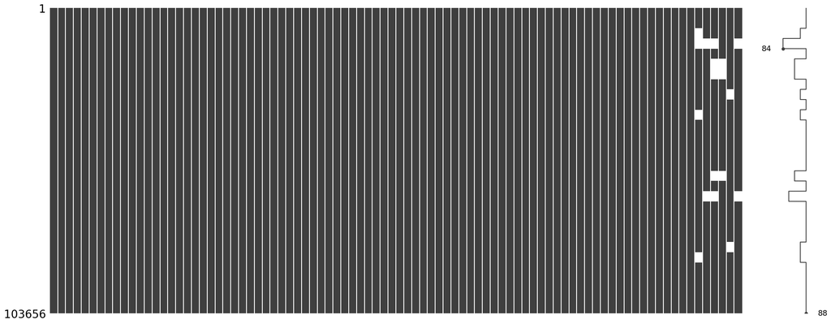

```python
msno.matrix(df_f)
```

Missing values were found in the dataset only for demographics variables only for demographics variables

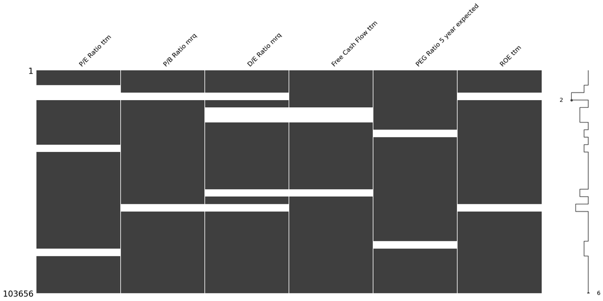

```python
msno.matrix(df_f[['P/E Ratio ttm', 'P/B Ratio mrq', 'D/E Ratio mrq',
       'Free Cash Flow ttm', 'PEG Ratio 5 year expected', 'ROE ttm']])
```

In phase 5 of this project, we will conduct additional analysis in this notebook to verify, analyze, and propose changes regarding the presence of missing values in demographic variables. Currently, it is observed that:

```python
miss=df_f[['P/E Ratio ttm', 'P/B Ratio mrq', 'D/E Ratio mrq',
       'Free Cash Flow ttm', 'PEG Ratio 5 year expected', 'ROE ttm']].isnull().sum()/103656*100
for n,i in enumerate(miss):
  print('The column "',miss.index[n],'" has {:.2f}% elements nulls'.format(i))
```

```
The column " P/E Ratio ttm " has 13.31% elements nulls
The column " P/B Ratio mrq " has 6.67% elements nulls
The column " D/E Ratio mrq " has 16.67% elements nulls
The column " Free Cash Flow ttm " has 10.00% elements nulls
The column " PEG Ratio 5 year expected " has 6.67% elements nulls
The column " ROE ttm " has 6.67% elements nulls
```

## Columns exploration

```python
def plot_hist(data,col,bins):
    """
    Function to Plot a histogram of a specified column from a DataFrame.
    """
  plt.figure(figsize=(10,5))
  sns.histplot(data=data,x=data[col],bins=bins,hue='stock_ID')
  plt.show()
```

```python
def plt_boxplot(data,col):
    """
    Function to plot a Boxplot of a specified column from a DataFrame.
    """
  plt.figure(figsize=(10,5))
  sns.boxplot(data=data,y=data[col],x='stock_ID')
  plt.title('Boxplot of {} values'.format(col))
  plt.xticks(rotation=90)
  plt.show()
```

```python
def plot_histograms(dataset, num_cols, num_rows):
    """
    Plots histograms for each numerical column in a given dataset.

    Args:
        dataset (DataFrame): The input dataset containing numerical columns.
        num_cols (int): The number of columns in the subplot grid.
        num_rows (int): The number of rows in the subplot grid.

    Returns:
        None. The histogram plot is displayed.

    Example:
        plot_histograms(stock_data, 4, 3)

    """
    num_plots = num_cols * num_rows
    num_features = dataset.shape[1]
    fig, axes = plt.subplots(num_rows, num_cols, figsize=(15, 120))
    fig.subplots_adjust(hspace=0.5)

    for i, ax in enumerate(axes.flatten()):
        if i < num_features:
            column = dataset.iloc[:, i]
            ax.hist(column.dropna(), bins=20, edgecolor='black', alpha=0.7)
            ax.set_title(column.name)
            ax.set_xlabel('Value')
            ax.set_ylabel('Frequency')
            ax.tick_params(axis='x', rotation=45)
        else:
            fig.delaxes(ax)

    plt.tight_layout()
    plt.show()
```

```python
def plot_boxplot(dataset, num_cols, num_rows):
    """
    Plots boxplots for each column in a given dataset.

    Args:
        dataset (DataFrame): The input dataset.
        num_cols (int): The number of columns in the subplot grid.
        num_rows (int): The number of rows in the subplot grid.

    Returns:
        None. The boxplot is displayed.

    Example:
        plot_boxplot(stock_data, 4, 3)

    """
    num_plots = num_cols * num_rows
    num_features = dataset.shape[1]
    fig, axes = plt.subplots(num_rows, num_cols, figsize=(15, 40))
    fig.subplots_adjust(hspace=0.5)

    for i, ax in enumerate(axes.flatten()):
        if i < num_features:
            column = dataset.iloc[:, i]
            ax.boxplot(column )
            ax.set_title(column.name)
            ax.set_xlabel('stocks')
            ax.set_ylabel('Price')
            ax.tick_params(axis='x', rotation=45)
        else:
            fig.delaxes(ax)

    plt.tight_layout()
    plt.show()
```

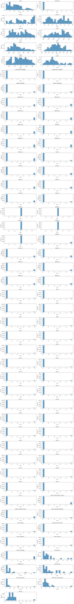

```python
plot_histograms(df_f.drop(['stock_ID'],axis=1), 2, int(len(df.columns)/2))
```

The following graph shows that each stock has unique value of the demographic P/E Ratio ttm over the time during 6 months from June 2022 to december 2022.

## Demographics Details

From June 2022 to December 2022, all demographic variables maintain the same value for each stock over a period of 6 months. As it is shown in the following graphs.

### P/E Ratio

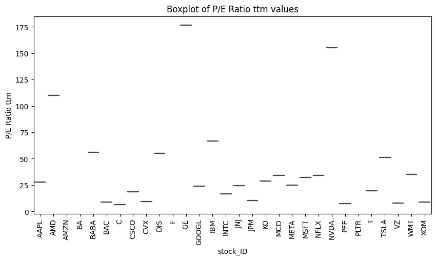

```python
plt_boxplot(df_f,'P/E Ratio ttm')
```

### P/B Ratio mrq

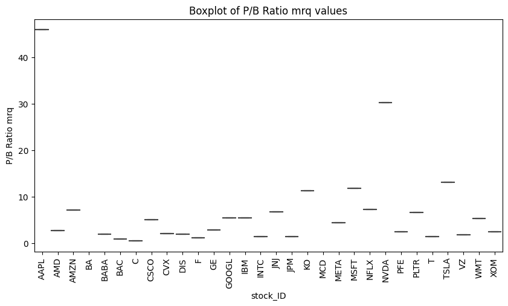

```python
plt_boxplot(df_f,'P/B Ratio mrq')
```

### D/E Ratio mrq

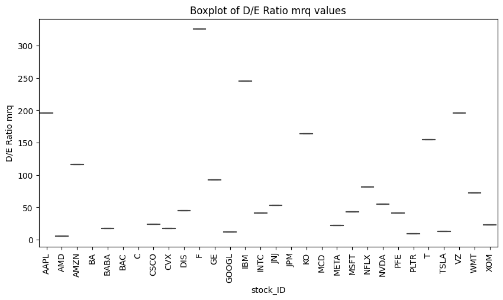

```python
plt_boxplot(df_f,'D/E Ratio mrq')
```

### Free Cash Flow ttm

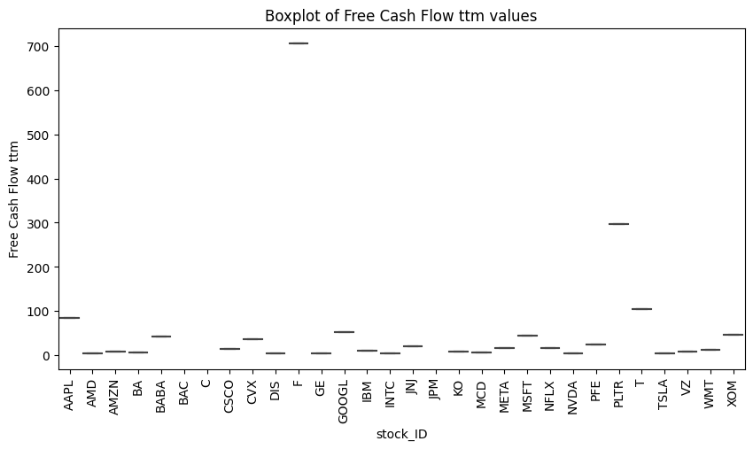

```python
plt_boxplot(df_f,'Free Cash Flow ttm')
```

### PEG Ratio 5 year expected

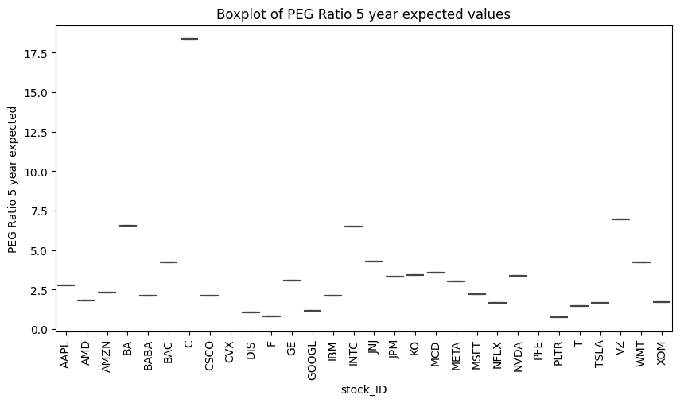

```python
plt_boxplot(df_f,'PEG Ratio 5 year expected')
```

### ROE ttm

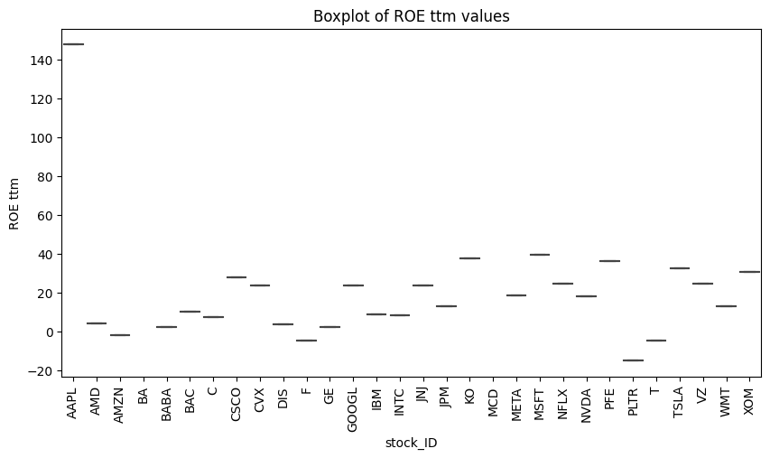

```python
plt_boxplot(df_f,'ROE ttm')
```

# Further Analysis

## Demographics values

It was discovered that although the data was intended to be collected for the time range from June 2022 to December 2022, the demographic variables actually correspond to a different date, specifically April 2023. This discrepancy occurred because the data extraction from Yahoo Finance, which was used for obtaining historical stock prices, does not provide historical datasets for demographic variables. As a result, the demographic values remain fixed and do not vary over time and some values does not correspond with the data was intented to collect. For accurate results and evaluation this should be fixed.

```python
dem_col=['stock_ID','P/E Ratio ttm', 'P/B Ratio mrq', 'D/E Ratio mrq',
       'Free Cash Flow ttm', 'PEG Ratio 5 year expected', 'ROE ttm']
```

```python
df_f.stock_ID.unique()
```

```
array(['AAPL', 'AMD', 'AMZN', 'BA', 'BABA', 'BAC', 'C', 'CSCO', 'CVX',
       'DIS', 'F', 'GE', 'GOOGL', 'IBM', 'INTC', 'JNJ', 'JPM', 'KO',
       'MCD', 'META', 'MSFT', 'NFLX', 'NVDA', 'PFE', 'PLTR', 'T', 'TSLA',
       'VZ', 'WMT', 'XOM'], dtype=object)
```

### Demographic data in April 2023: Addressing missing values.

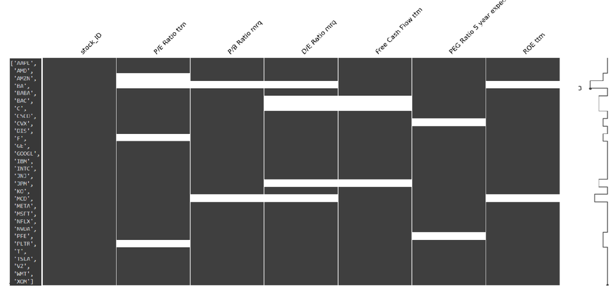

#### AMZN

Values when demographic data in april 2023

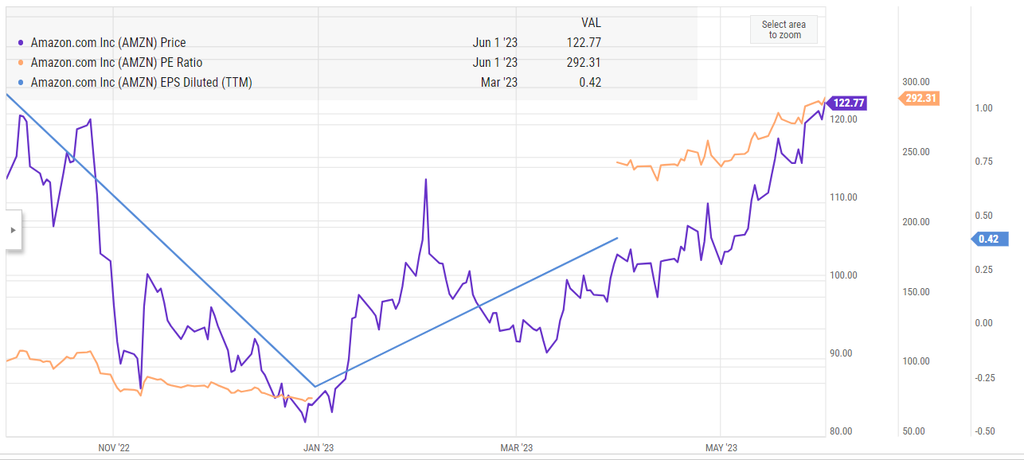

The calculation of the price-to-earnings (P/E) ratio is based on the formula:

P/E ratio = Market Price per Share / Earnings per Share (EPS)

Values when demographic data in 2022

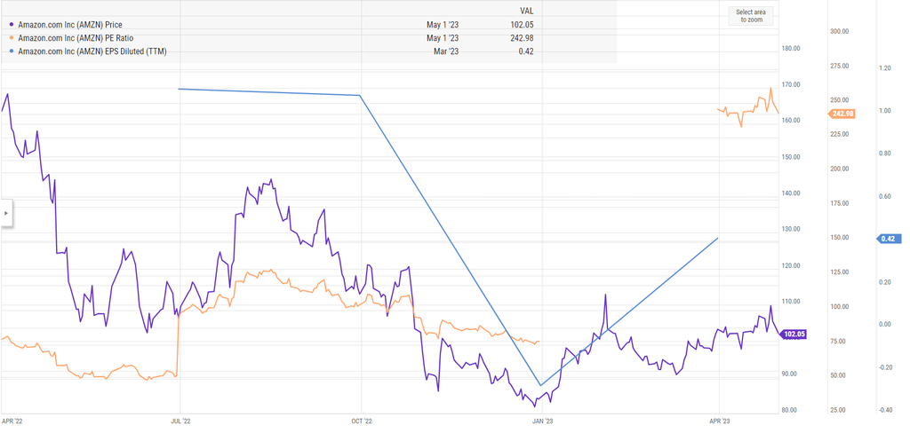

The P/E ratio (Price-to-Earnings ratio) changes over time, and it can be calculated using the formula:

P/E ratio = Market Price per Share / Earnings per Share (EPS)

#### BA

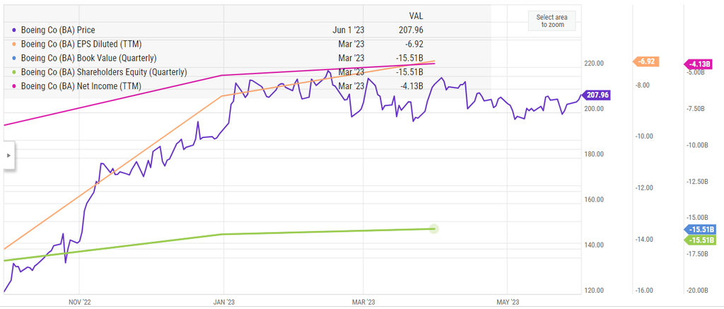

PE ratio is not reported since Earnings Per Share (EPS) TTM is negative  
P/B Ratio mrq is not reported since Book value Quarterly is negative  
D/E Ratio mrq is not reported since Shareholders Equity Quarterly is negative  
ROE ttm is not reported since Net Income (TTM) is negative

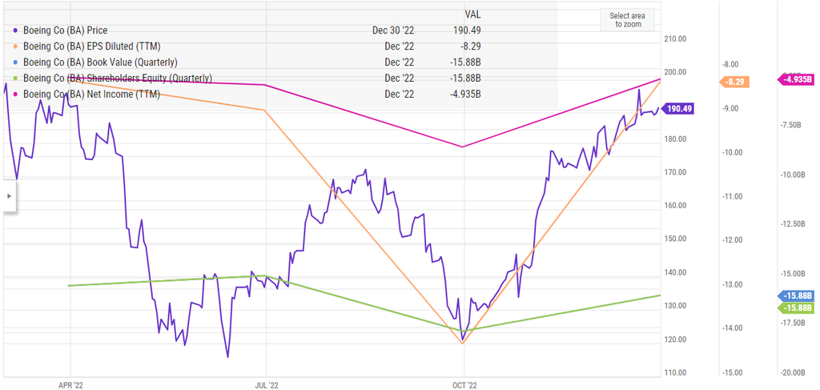

- PE ratio is not reported since Earnings Per Share (EPS) TTM is negative
- P/B Ratio mrq is not reported since Book value Quarterly is negative
- D/E Ratio mrq is not reported since Shareholders Equitu Quarterly is negative
- ROE ttm is not reported since Ne Income (TTM) is negative

#### BAC

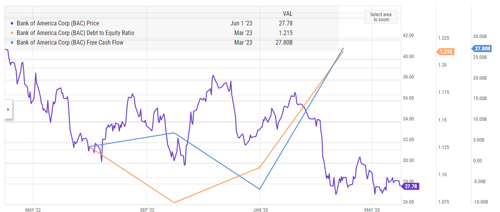

#### JPM

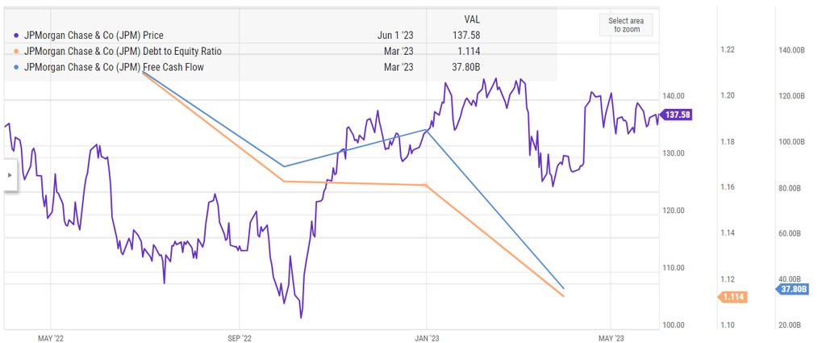

D/E Ratio mrq: From June 2022 was not reported any value, however, between July 2022 to December 2022,D/E Ratio mrq was reported as a range of 1.22 to 1.164. By April 2023, the ratio had the value of 1.114 B

#### MCD

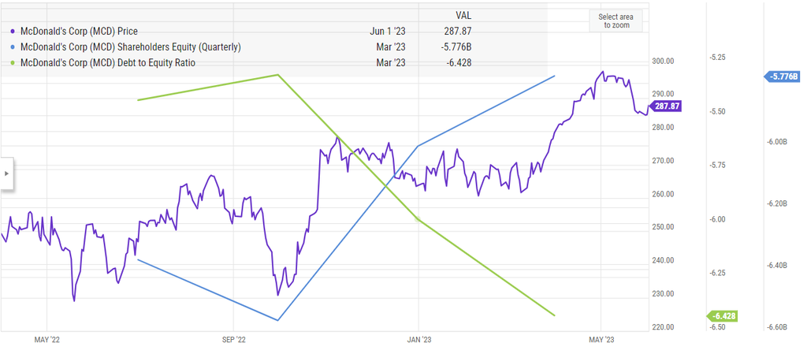

#### PLTR

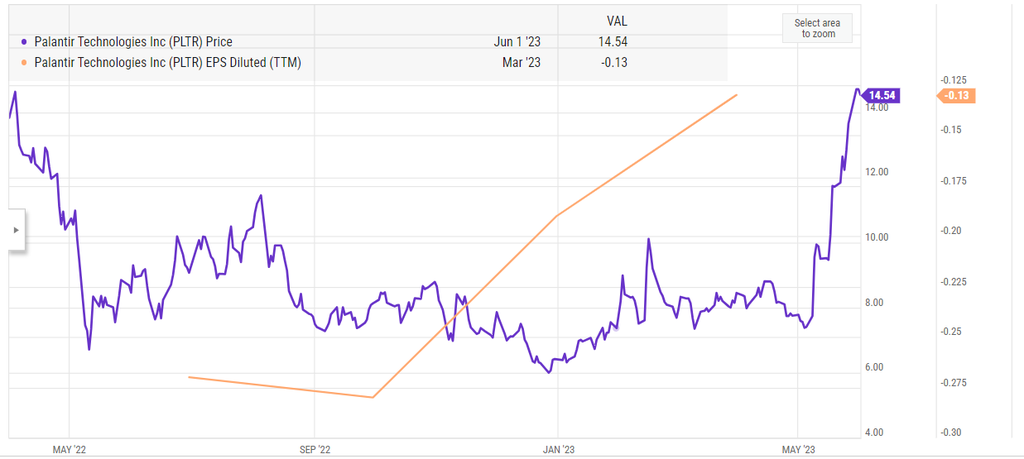

From June 2022 to April 2023 PE ratio was not reported since Earnings Per Share (EPS) TTM is negative

#### C

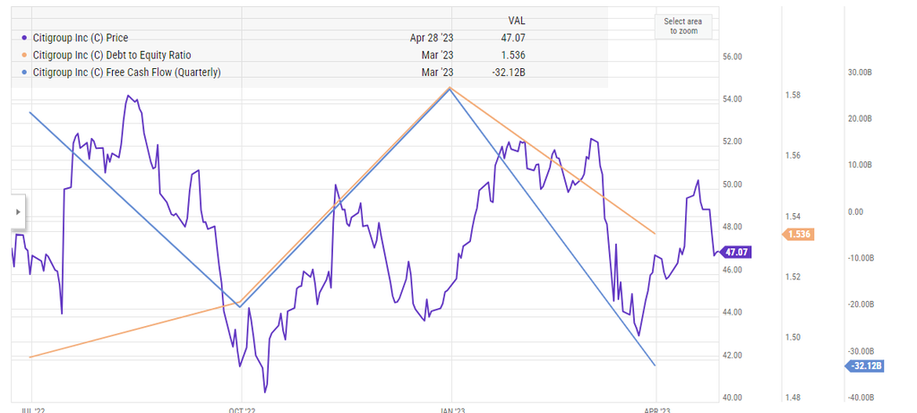

During June to September 2022, the cash flow was 22.25 billion USD. From September to December 2022, it declined to -19.62 billion USD. In April 2023, the cash flow decreased to -32.12 billion USD.

#### MCD

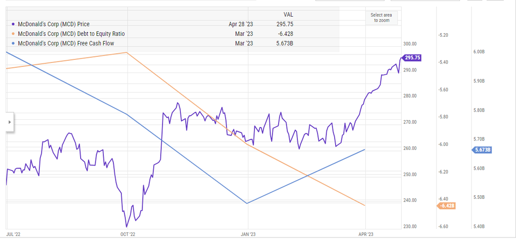

#### JPM

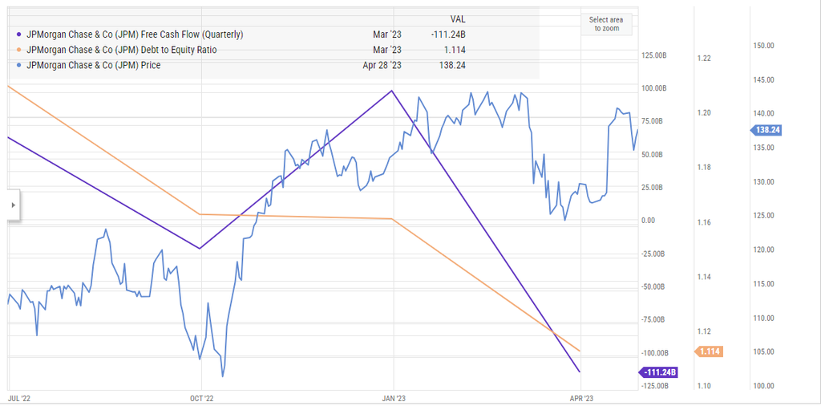

From June to September 2022, JPM's D/E ratio decreased from 1.211 to 1.164. By April 2023, the ratio further decreased to 1.114.

In terms of cash flow, it was positive at 66.02 billion USD from June to September 2022. However, from September to December 2022, the cash flow turned negative, standing at -18.20 billion USD. By April 2023, the negative cash flow deepened significantly to -111.24 billion USD.

#### F

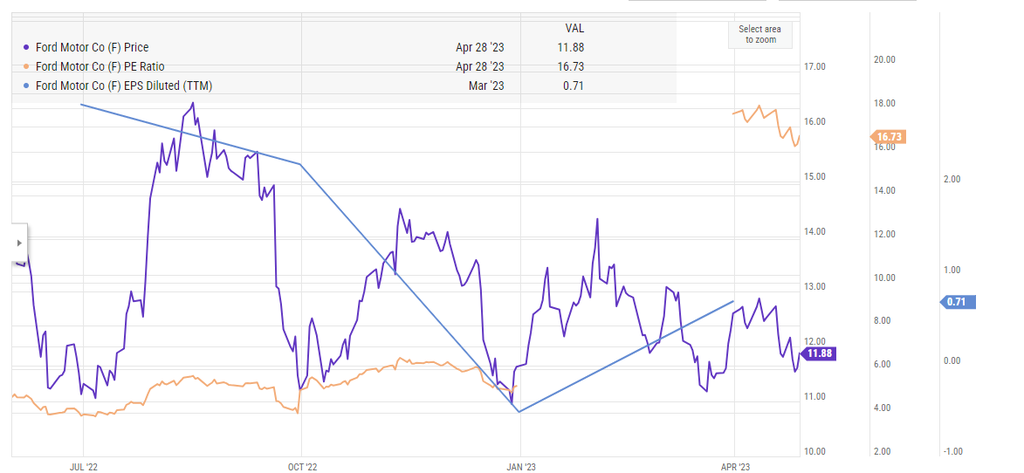

For the time period Between jun 2022 and December 2022 The PE ratio ranges from 6.44 to 3.913

#### CVX & PFE

The price/earnings to growth ratio (PEG ratio) is a stock's price-to-earnings (P/E) ratio divided by the growth rate of its earnings for a specified time period.

The PEG ratio is used to determine a stock's value while also factoring in the company's expected earnings growth, and it is thought to provide a more complete picture than the more standard P/E ratio.

PEG ratio is unavailable and for a given company may differ significantly from one reported source to another.